# Data Challenge competition - Football prediction

Attila Gulyás / Team Bella Vita

Note: - Data was provided by the organizer of the competition. It is found to be clean, no missing values, no duplicates. - There are 23 divisions and 10 seasons in the data.

BASIC SETUP

```r
# empty memory
rm(list=ls())

# KOMMENT: install library if not exist -> megoldani majd

# Load libraries
library("tidyverse") # imap function for roc curve
library("data.table") # to use data in an efficient way
library("readxl") # to read xlsx data
library("caret") # to split data into train and holdput sets
library("dplyr") # to append commands easier
library("ROCR") # to evaluate model performance
library("h2o") # for autoML, java is kell hozzá
library("xgboost") # for extreme gradient boosting model
library("e1071") # for Naive Bayes
library("ranger") # for RF model
library("kernlab") # for SVM
library("mltools") # to calculate AUC manually
library("glmnet") # for GLMNET model
# library(ggplot2)
# library(ggthemes)
# library(grid)
# library(lattice)
# library(glmnet)
# library("skimr")
# library(gridExtra)

# Set the working directory
dir <-  "/Users/attilagulyas/Documents/GitHub/DataChallenge2023/"

#location folders
data_in <- paste0(dir,"01_raw/")
# func <- paste0(dir, "work/") - nem használt
output <- paste0(dir, "04_output/")
```

LOAD DATA

```r
data <- as.data.table(read_excel(paste0(data_in, "competition_table.xlsx")))


# BASIC STISTICS
message(paste0("Döntetlen aránya: ", round(sum(data$draw_flag) / nrow(data), digits = 2)))
```

```
Döntetlen aránya: 0.26
```

```r
message(paste0("Hazai győzelem aránya: ", round(sum(data$home_win_flag) / nrow(data), digits = 2)))
```

```
Hazai győzelem aránya: 0.44
```

```r
message(paste0("Vendég győzelem aránya: ", round(sum(data$away_win_flag) / nrow(data), digits = 2)))
```

```
Vendég győzelem aránya: 0.3
```

LABEL ENGINEERING

```r
data <- data %>%
  mutate(home_win_flag = factor(ifelse(home_win_flag == 0, "no", "yes"), levels = c("no", "yes")))

data <- data %>%
  mutate(away_win_flag = factor(ifelse(away_win_flag == 0, "no", "yes"), levels = c("no", "yes")))

data <- data %>%
  mutate(draw_flag = factor(ifelse(draw_flag == 0, "no", "yes"), levels = c("no", "yes")))
```

FEATURE ENGINEERING

```r
# data structure
# str(data)
data <- data %>% mutate(
        # hazai csapat támadás erőssége előző meccsen
        home_goal_per_shot_roll1 = home_team_goal_roll1_sum / home_team_shot_roll1_sum,
        home_goal_per_shotontarget_roll1 = home_team_goal_roll1_sum / home_team_shot_on_target_roll1_sum,
        home_shotontarget_per_shots_roll1 = home_team_shot_on_target_roll1_sum / home_team_shot_roll1_sum,
        # hazai csapat támadás erőssége előző 4 meccsen
        home_goal_per_shot_roll4 = home_team_goal_roll4_sum / home_team_shot_roll4_sum,
        home_goal_per_shotontarget_roll4 = home_team_goal_roll4_sum / home_team_shot_on_target_roll4_sum,
        home_shotontarget_per_shots_roll4 = home_team_shot_on_target_roll4_sum / home_team_shot_roll4_sum,
        # vendég csapat támadás erőssége előző meccsen
        away_goal_per_shot_roll1 = away_team_goal_roll1_sum / away_team_shot_roll1_sum,
        away_goal_per_shotontarget_roll1 = away_team_goal_roll1_sum / away_team_shot_on_target_roll1_sum,
        away_shotontarget_per_shots_roll1 = away_team_shot_on_target_roll1_sum / away_team_shot_roll1_sum,
        # vendég csapat támadás erőssége előző 4 meccsen
        away_goal_per_shot_roll4 = away_team_goal_roll4_sum / away_team_shot_roll4_sum,
        away_goal_per_shotontarget_roll4 = away_team_goal_roll4_sum / away_team_shot_on_target_roll4_sum,
        away_shotontarget_per_shots_roll4 = away_team_shot_on_target_roll4_sum / away_team_shot_roll4_sum,

        # hazai csapat védekezés erőssége előző meccsen
        home_opponents_goal_per_shot_roll1 =
          home_team_opponents_goal_roll1_sum / home_team_opponents_shot_roll1_sum,
        home_opponents_goal_per_shotontarget_roll1 =
          home_team_opponents_goal_roll1_sum /     home_team_opponents_shot_on_target_roll1_sum,
        home_opponents_shotontarget_per_shots_roll1 =
          home_team_opponents_shot_on_target_roll1_sum / home_team_opponents_shot_roll1_sum,

        # hazai csapat védekezés erőssége előző 4 meccsen
        home_opponents_goal_per_shot_roll4 =
          home_team_opponents_goal_roll4_sum / home_team_opponents_shot_roll4_sum,
        home_opponents_goal_per_shotontarget_roll4 =
          home_team_opponents_goal_roll4_sum /     home_team_opponents_shot_on_target_roll4_sum,
        home_opponents_shotontarget_per_shots_roll4 =
          home_team_opponents_shot_on_target_roll4_sum / home_team_opponents_shot_roll4_sum,

        # vendég csapat védekezés erőssége előző meccsen
        away_opponents_goal_per_shot_roll1 =
          away_team_opponents_goal_roll1_sum / away_team_opponents_shot_roll1_sum,
        away_opponents_goal_per_shotontarget_roll1 =
          away_team_opponents_goal_roll1_sum /     away_team_opponents_shot_on_target_roll1_sum,
        away_opponents_shotontarget_per_shots_roll1 =
          away_team_opponents_shot_on_target_roll1_sum / away_team_opponents_shot_roll1_sum,

        # vendég csapat védekezés erőssége előző 4 meccsen
        away_opponents_goal_per_shot_roll4 =
          away_team_opponents_goal_roll4_sum / away_team_opponents_shot_roll4_sum,
        away_opponents_goal_per_shotontarget_roll4 =
          away_team_opponents_goal_roll4_sum /     away_team_opponents_shot_on_target_roll4_sum,
        away_opponents_shotontarget_per_shots_roll4 =
          away_team_opponents_shot_on_target_roll4_sum / away_team_opponents_shot_roll4_sum
)


# nullás osztás miatti hibás értékek javítása
data[,168:191] <- lapply(data[,168:191], function(x) {x[is.infinite(x)] <- 0; return(x)}) %>% as.data.table()
data[,168:191] <- lapply(data[,168:191], function(x) {x[is.na(x)] <- 0; return(x)}) %>% as.data.table()
```

| MODEL FOR PREDICTING HOME WIN |
| --- |

Create training set and holdout set samples Megj: 80%os trainingsettel is kipróbálni!

```r
set.seed(1990)

# smaller than usual training set so that models run faster
train_indices <- createDataPartition(data$home_win_flag, p = 0.7, list = FALSE)
data_train <- data[train_indices, ]

data_holdout <- data[-train_indices, ]

dim(data_train)
```

```
[1] 44917   191
```

```r
dim(data_holdout)
```

```
[1] 19249   191
```

Set evaluation rules Megj: 10-fold CV, repeated CV is megoldás lehet, kipróbálni

```r
train_control <- trainControl(
  method = "cv",
  n = 5,
  classProbs = TRUE,
  summaryFunction = twoClassSummary  # necessary!
)

# MEGJ: repeated CV is egy megoldás

# Define the control parameters for the train function
# ctrl <- trainControl(method = "repeatedcv", number = 10, repeats = 3,
#                      classProbs = TRUE, summaryFunction = twoClassSummary)
```

Define variables

```r
# Basic numeric variables
basic_numeric_vars <- c(
  "odds_home_team_win",
  "odds_away_team_win",
  "odds_draw"
)

# glmnet (elastic net penalized) based selection
basic_numeric_vars_set2 <- c("odds_away_team_win",
                             "odds_home_team_win",

                             "home_team_expected_point_roll4_sum",
                              "away_team_expected_point_roll4_sum",
                              "away_team_expected_point_roll3_sum",
                              "away_team_expected_point_mean",

                              "home_team_corner_roll4_sum", # ?
                              "home_team_corner_roll3_sum", # ?
                              "home_team_corner_roll2_sum", # ?
                              "away_team_opponents_corner_roll4_sum", # ?
                              "home_team_opponents_corner_roll2_sum", # ?

                              "home_team_shot_roll2_sum", # ?
                              "away_team_opponents_shot_roll1_sum",  # ?
                              "away_team_opponents_shot_roll4_sum", # ?
                              "away_team_opponents_shot_roll3_sum", # ?

                              "away_team_opponents_shot_on_target_roll4_sum",
                             )

# xgb based selection
basic_numeric_vars_set3 <- c("odds_away_team_win",
                             "odds_home_team_win",
                             "odds_draw",

                             "odds_home_team_defeat_roll4_mean",
                             "odds_home_team_defeat_roll3_mean", # human input
                             "odds_home_team_defeat_roll2_mean",

                             "odds_away_team_defeat_roll4_mean",
                             "odds_away_team_defeat_roll3_mean", # human input
                             "odds_away_team_defeat_roll2_mean", # human input

                             "odds_away_team_win_roll4_mean",
                             "odds_away_team_win_roll3_mean",

                             "odds_home_team_win_roll4_mean", # human input
                             "odds_home_team_win_roll3_mean",

                              "odds_home_team_draw_roll4_mean",
                             "odds_home_team_draw_roll3_mean", # human input
                             "odds_away_team_draw_roll4_mean", # human input
                             "odds_away_team_draw_roll3_mean",

                              "away_team_expected_point_mean",
                             "home_team_expected_point_mean", # human input
                              "home_team_corner_roll3_sum", # ?
                              "away_team_corner_roll2_sum", # ?
                              "away_team_opponents_corner_roll4_sum", # ?

                             "home_team_shot_roll2_sum", # ?
                             "home_team_shot_roll4_sum", # ?
                             "home_shotontarget_per_shots_roll4",
                             "away_team_opponents_shot_roll4_sum", # ?
                             "away_team_opponents_shot_on_target_roll3_sum"

                             )

# rnadom forest based selection
basic_numeric_vars_set4 <- c("odds_away_team_win",
                             "odds_home_team_win",
                             "odds_draw",
                             "odds_home_team_defeat_roll4_mean",
                             "odds_home_team_defeat_roll3_mean",
                             "odds_home_team_defeat_roll2_mean",
                             "odds_away_team_defeat_roll1_mean",

                             "odds_away_team_defeat_roll4_mean",
                             "odds_away_team_defeat_roll3_mean",
                             "odds_away_team_defeat_roll2_mean",

                             "odds_home_team_win_roll4_mean",
                             "odds_home_team_win_roll3_mean",
                             "odds_home_team_win_roll2_mean",

                             "odds_away_team_win_roll4_mean",
                             "odds_away_team_win_roll3_mean",
                             "odds_away_team_win_roll2_mean",

                             "odds_away_team_draw_roll4_mean",

                             "home_team_expected_point_roll4_sum",
                             "away_team_expected_point_roll4_sum",  # human input
                             "away_team_expected_point_mean",
                             "home_team_expected_point_mean",
                             )

# Log variables
# Higher order variables
# Factorized variables
# Dummy variables
```

Define predictor sets

```r
predictors_1 <- c(basic_numeric_vars)
predictors_2 <- colnames(data[,-c("home_win_flag", "draw_flag", "away_win_flag", "match_id")])
predictors_3 <- c(basic_numeric_vars_set2)
```

| MODELLEK: |
| --- |

```r
# Basic numeric variables
basic_numeric_vars <- c(
  "odds_home_team_win",
  "odds_away_team_win",
  "odds_draw"
)

basic_numeric_vars_set2 <- c("odds_away_team_win",
                             "odds_home_team_win",
                             "odds_draw",

                             "odds_home_team_defeat_roll4_mean",
                             "odds_away_team_defeat_roll4_mean",
                             "odds_home_team_win_roll4_mean",
                             "odds_away_team_win_roll4_mean",

                             "odds_home_team_defeat_roll3_mean",
                             "odds_away_team_defeat_roll3_mean",
                             "odds_home_team_win_roll3_mean",
                             "odds_away_team_win_roll3_mean",

                             "odds_home_team_defeat_roll2_mean",
                             "odds_away_team_defeat_roll2_mean",
                             "odds_home_team_win_roll2_mean",
                             "odds_away_team_win_roll2_mean",

                             "odds_home_team_defeat_roll1_mean",
                             "odds_away_team_defeat_roll1_mean",
                             "odds_home_team_win_roll1_mean",
                             "odds_away_team_win_roll1_mean",

                             "home_team_expected_point_mean",
                             "away_team_expected_point_mean",
                             "home_team_expected_point_roll4_sum",
                             "away_team_expected_point_roll4_sum"
                             )

# Log variables

# Higher order variables

# Factorized variables

# Dummy variables
```

## Logistic regression

megj: a változószelekción még dolgozni kell: 1) domain knowledge

```r
#  train the model
set.seed(857)

glm_model <- train(home_win_flag ~ .,
                   data = data_train[ ,colnames(data_train) %in% c("home_win_flag", predictors_1), with=FALSE],
                   method = "glm",
                   trControl = train_control)
```

```r
# model summary
summary(glm_model)
```

```r
# AUC on validation set
auc_cv <- glm_model[["results"]][["ROC"]]
message(paste0("AUC from CV: ", round(auc_cv, digits = 4)))
```

```
AUC from CV: 0.6814
```

```r
# variable importance
varimp <- varImp(glm_model)
plot(varImp(glm_model))
```

[output not shown]

## GLMNET model (Reguralized logistic regression)

```r
#  train the model
set.seed(857)

tune_grid_glmnet <- expand.grid(
               alpha = 0.9, #seq(from = 0, to = 1, by = 0.1), #ridge: 0, lasso: 1, elastic net: [0,1]
               lambda = 0.01 # seq(0.0001, 1, length = 100)
)

glmnet_model <- train(home_win_flag ~ .,
                   data = data_train[ ,colnames(data_train) %in% c("home_win_flag", predictors_2), with=FALSE],
                   method = "glmnet",
                   trControl = train_control,
                   tuneGrid = tune_grid_glmnet)
```

```r
# find the best parameters

best_lambda<- glmnet_model$bestTune$lambda
message(paste0(" best lambda: ", round(best_lambda, digits = 4)))
```

```
 best lambda: 0.01
```

```r
best_alpha<- glmnet_model$bestTune$alpha
message(paste0(" best alpha: ", round(best_alpha, digits = 4)))
```

```
 best alpha: 0.9
```

```r
# AUC on validation set
auc_cv <- glmnet_model[["results"]][["ROC"]]
message(paste0("AUC from CV: ", round(auc_cv, digits = 4)))
```

```
AUC from CV: 0.6818
```

```r
# model summary
# summary(glmnet_model)
```

[figure not shown]

```r
# variable importance
varimp <- varImp(glmnet_model)
plot(varImp(glmnet_model))
```

```r
varimp
```

```
glmnet variable importance

  only 20 most important variables shown (out of 219)
```

|  | Overall |
| --- | --- |
| odds_home_team_win | 1.000000e+02 |
| odds_away_team_win | 5.339228e+01 |
| home_team_expected_point_roll4_sum | 2.228196e+00 |
| home_team_corner_roll4_sum | 1.097488e+00 |
| away_team_opponents_corner_roll4_sum | 8.439041e-01 |
| home_team_shot_roll2_sum | 7.729045e-01 |
| home_team_corner_roll2_sum | 6.741984e-01 |
| home_team_corner_roll3_sum | 6.383204e-01 |
| away_team_expected_point_roll3_sum | 4.215207e-01 |
| away_team_opponents_shot_roll1_sum | 3.562228e-01 |

[output cut: 10 more lines]

## Extreme Gradient Boosting

```r
#  train the model
set.seed(19900829)
tune_grid_xgb <- expand.grid(
  nrounds = c(10,100),  # this is n_estimators in python code
  max_depth = c(3,10),
  colsample_bytree = seq(0.5, 0.9, length.out = 5),
  ## The values below are default values in the sklearn-api.
  eta = c(0.01, 0.1),
  gamma=c(0,10),
  min_child_weight = c(1,10),
  subsample = c(0.5,1)
)


xgb_model <- train(
  home_win_flag ~ .,
  data = data_train[ ,colnames(data_train) %in% c("home_win_flag", predictors_2), with=FALSE],
  tuneLength = 1,
  method = 'xgbTree',
  na.action = na.omit,
  # importance = 'permutation',
  # mtry: cannot be more than the number of predictors
  tuneGrid = tune_grid_xgb,
  trControl = train_control)
```

[output not shown]

[output cut: 1545 more lines]

[output not shown]

```r
# find the best parameters
best_nrounds <- xgb_model$bestTune$nrounds
message(paste0(" best nrounds: ", round(best_nrounds, digits = 4)))
```

```
 best nrounds: 100
```

```r
best_max_depth <- xgb_model$bestTune$max_depth
message(paste0(" best max_depth : ", round(best_max_depth, digits = 4)))
```

```
 best max_depth : 3
```

```r
best_colsample_bytree <- xgb_model$bestTune$colsample_bytree
message(paste0(" best colsample_bytree : ", round(best_colsample_bytree, digits = 4)))
```

```
 best colsample_bytree : 0.8
```

```r
best_eta <- xgb_model$bestTune$eta
message(paste0(" best eta : ", round(best_eta, digits = 4)))
```

```
 best eta : 0.1
```

```r
best_gamma<- xgb_model$bestTune$gamma
message(paste0(" best gamma : ", round(best_gamma, digits = 4)))
```

```
 best gamma : 10
```

```r
best_min_child_weight<- xgb_model$bestTune$min_child_weight
message(paste0(" best min_child_weight : ", round(best_min_child_weight, digits = 4)))
```

```
 best min_child_weight : 10
```

```r
best_subsample<- xgb_model$bestTune$subsample
message(paste0(" best subsample : ", round(best_subsample, digits = 4)))
```

```
 best subsample : 1
```

```r
# AUC on validation set
auc_cv <- xgb_model[["results"]][["ROC"]]
message(paste0("AUC from CV: ", round(auc_cv, digits = 4)))
```

[output not shown]

```r
# model summary
# summary(xgb_model)
```

[figure not shown]

```r
# variable importance
varimp <- varImp(xgb_model)
plot(varImp(xgb_model))
```

```r
varimp
```

```
xgbTree variable importance

  only 20 most important variables shown (out of 219)
```

|  | Overall |
| --- | --- |
| odds_home_team_win | 100.0000000 |
| odds_away_team_win | 16.9197591 |
| odds_home_team_defeat_roll4_mean | 11.9811760 |
| odds_draw | 7.6907857 |
| away_team_expected_point_mean | 5.2218046 |
| odds_away_team_defeat_roll4_mean | 2.9296598 |
| odds_home_team_win_roll3_mean | 1.1441239 |
| home_team_corner_roll3_sum | 1.0012577 |
| odds_away_team_win_roll3_mean | 0.7711146 |
| away_team_opponents_corner_roll4_sum | 0.7547633 |

[output cut: 10 more lines]

## “Simple” Gradient Boosting Machine

```r
#  train the model
set.seed(19900829)
tune_grid_gbm <- expand.grid(n.trees = c(100, 200),
                        interaction.depth = c(5, 10),
                        shrinkage = c(0.005, 0.01, 0.1),
                        n.minobsinnode = c(5, 50))

gbm_model <- train(home_win_flag ~ .,
                   data = data_train[ ,colnames(data_train) %in% c("home_win_flag", predictors_2), with=FALSE],
                   method = "gbm",
                   trControl = train_control,
                   tuneGrid = tune_grid_gbm,
                   bag.fraction = 0.8,
                   verbose = FALSE # gbm by default prints too much output
)
```

```r
# find the best parameters
best_n.trees <- gbm_model$bestTune$n.trees
message(paste0(" best n.trees: ", round(best_n.trees, digits = 4)))
```

```
 best n.trees: 200
```

```r
best_interaction.depth <- gbm_model$bestTune$interaction.depth
message(paste0(" best interaction.depth: ", round(best_interaction.depth, digits = 4)))
```

```
 best interaction.depth: 5
```

```r
best_shrinkage <- gbm_model$bestTune$shrinkage
message(paste0(" best shrinkage: ", round(best_shrinkage, digits = 4)))
```

```
 best shrinkage: 0.01
```

```r
best_n.minobsinnode <- gbm_model$bestTune$n.minobsinnode
message(paste0(" best n.minobsinnode: ", round(best_n.minobsinnode, digits = 4)))
```

```
 best n.minobsinnode: 50
```

```r
# AUC on validation set
auc_cv <- gbm_model[["results"]][["ROC"]]
message(paste0("AUC from CV: ", round(auc_cv, digits = 4)))
```

[output not shown]

```r
# model summary
# summary(gbm_model)
```

```r
varimp <- varImp(gbm_model)
```

```
Error in relative.influence(object, n.trees = numTrees) :
  could not find function "relative.influence"
```

## Naive Bayes

```r
#  train the model
set.seed(19900829)

nb_model <- train(home_win_flag ~ .,
                  data = data_train[ ,colnames(data_train) %in% c("home_win_flag", predictors_2), with=FALSE],
                  method = "naive_bayes",
                  trControl = train_control, verbose = FALSE)
```

[output not shown]

[output cut: 2574 more lines]

[output not shown]

```r
# model summary
summary(nb_model)
```

```r
# AUC on validation set
auc_cv <- nb_model[["results"]][["ROC"]]
message(paste0("AUC from CV: ", round(auc_cv, digits = 4)))
```

```
AUC from CV: 0.6588AUC from CV: 0.6619
```

```r
varimp <- varImp(nb_model)
plot(varImp(nb_model))
```

[output not shown]

## Random Forest

```r
#  train the model
set.seed(19900829)
tune_grid_rf <- expand.grid(
  .mtry = c(3,10,20),
  .splitrule = "gini", # variance
  .min.node.size = c(5, 500) # 1 % of training set
)


rf_model <- train(
  home_win_flag ~ .,
  data = data_train[ ,colnames(data_train) %in% c("home_win_flag", predictors_2), with=FALSE],
  tuneLength = 1,
  method = 'ranger',
  na.action = na.omit,
  importance = 'permutation',
  # mtry: cannot be more than the number of predictors
  tuneGrid = tune_grid_rf,
  trControl = train_control)
```

```r
# find the best parameters
best_mtry <- rf_model$bestTune$mtry
message(paste0(" best mtry: ", round(best_mtry, digits = 4)))
```

```
 best mtry: 20
```

```r
best_min.node.size<- rf_model$bestTune$min.node.size
message(paste0(" best min.node.size: ", round(best_min.node.size, digits = 4)))
```

```
 best min.node.size: 500
```

```r
# AUC on validation set
auc_cv <- rf_model[["results"]][["ROC"]]
message(paste0("AUC from CV: ", round(auc_cv, digits = 4)))
```

```
AUC from CV: 0.67AUC from CV: 0.6717AUC from CV: 0.6732AUC from CV: 0.677AUC from CV: 0.6739AUC from CV: 0.6793
```

```r
# model summary
summary(rf_model)
```

[figure not shown]

```r
varimp <- varImp(rf_model)
plot(varImp(rf_model))
```

```r
varimp
```

```
ranger variable importance

  only 20 most important variables shown (out of 219)
```

|  | Overall |
| --- | --- |
| odds_home_team_win | 100.000000 |
| odds_away_team_win | 87.675242 |
| odds_draw | 22.408495 |
| odds_home_team_defeat_roll4_mean | 21.611063 |
| odds_away_team_defeat_roll4_mean | 17.271035 |
| odds_home_team_defeat_roll3_mean | 16.609124 |
| odds_home_team_win_roll4_mean | 13.955389 |
| odds_away_team_win_roll4_mean | 13.361329 |
| odds_away_team_defeat_roll3_mean | 13.175351 |
| away_team_expected_point_mean | 12.984823 |

[output cut: 10 more lines]

## SVM

```r
#  train the model
set.seed(19900829)
tune_grid_svm <- expand.grid(
  .C = c(0.001, 0.01, 0.1, 1)
)


svm_model <- train(
  home_win_flag ~ .,
  data = data_train[ ,colnames(data_train) %in% c("home_win_flag", predictors_3), with=FALSE],
  tuneLength = 1,
  method = 'svmLinear',
  na.action = na.omit,
  importance = 'permutation',
  # mtry: cannot be more than the number of predictors
  tuneGrid = tune_grid_svm,
  trControl = train_control)
```

```r
# find the best parameters
best_C<- svm_model$bestTune$C
message(paste0(" best C: ", round(best_C, digits = 4)))
```

```
 best C: 0.01
```

```r
# model summary
summary(svm_model)
```

```r
# AUC on validation set
auc_cv <- svm_model[["results"]][["ROC"]]
message(paste0("AUC from CV: ", round(auc_cv, digits = 4)))
```

```
AUC from CV: 0.6771AUC from CV: 0.6771AUC from CV: 0.6769AUC from CV: 0.6768
```

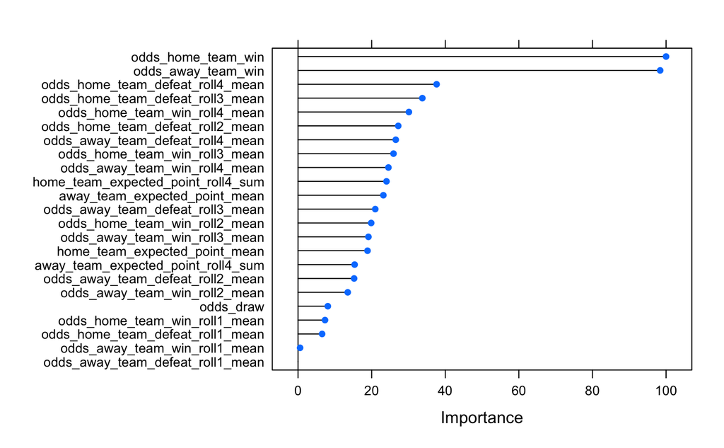

```r
varimp <- varImp(svm_model)
plot(varImp(svm_model))
```

## K-Nearest Neighbours

```r
#  train the model
set.seed(19900829)
tune_grid_knn <- expand.grid(
  .k= c(5, 10)
)


knn_model <- train(
  home_win_flag ~ .,
  data = data_train[ ,colnames(data_train) %in% c("home_win_flag", predictors_1), with=FALSE],
  tuneLength = 1,
  method = 'knn',
  na.action = na.omit,
  # importance = 'permutation',
  # mtry: cannot be more than the number of predictors
  tuneGrid = tune_grid_knn,
  trControl = train_control)
```

```r
# find the best parameters
best_k<- knn_model$bestTune$k
message(paste0(" best k: ", round(best_k, digits = 4)))
```

```
 best k: 10
```

```r
# Tune k-NN model using cross-validation
knn_tune <- tune.knn(x, y, k = 1:2, tunecontrol = tune.control(sampling = "cross"))
```

```
Error in tune("knn.wrapper", train.x = x, train.y = y, ranges = ranges,  :
  Dependent variable has wrong type!
```

```r
# model summary
summary(knn_model)
```

```r
# AUC on validation set
auc_cv <- knn_model[["results"]][["ROC"]]
message(paste0("AUC from CV: ", round(auc_cv, digits = 4)))
```

```
AUC from CV: 0.6307AUC from CV: 0.6452
```

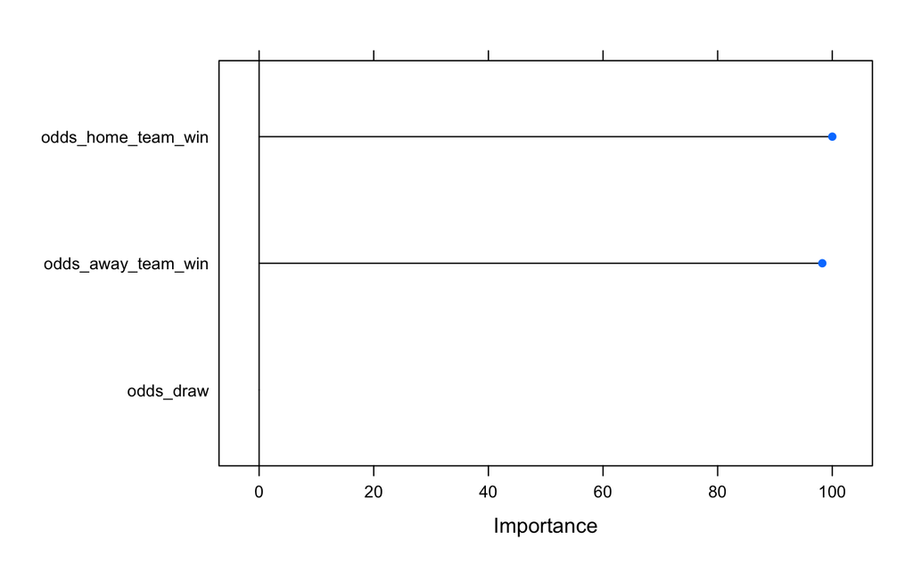

```r
varimp <- varImp(knn_model)
plot(varImp(knn_model))
```

## ENSEMBLED MODEL

```r
h2o.init()
```

[output not shown]

[output not shown]

[output not shown]

```r
data_train_h2o <- as.h2o(data_train[,-c("away_win_flag", "draw_flag")])
# Identify predictors and response
y <- "home_win_flag"
x <- predictors_2

# Train & Cross-validate a GBM
my_gbm <- h2o.gbm(x = x,
                  y = y,
                  training_frame = data_train_h2o,
                  nfolds = 5,
                  keep_cross_validation_predictions = TRUE,
                  seed = 5)
# Train & Cross-validate a RF
my_rf <- h2o.randomForest(x = x,
                          y = y,
                          training_frame = data_train_h2o,
                          nfolds = 5,
                          keep_cross_validation_predictions = TRUE,
                          seed = 5)
# Train & Cross-validate a LR
my_lr <- h2o.glm(x = x,
                 y = y,
                 training_frame = data_train_h2o,
                 family = c("binomial"),
                 nfolds = 5,
                 keep_cross_validation_predictions = TRUE,
                 seed = 5)
# Train a stacked random forest ensemble using the GBM, RF and LR above
ensemble <- h2o.stackedEnsemble(x = x,
                                y = y,
                                metalearner_algorithm="drf",
                                training_frame = data_train_h2o,
                                base_models = list(my_gbm, my_rf, my_lr))
```

```r
# model summary
summary(ensemble)
```

```
Model Details:
==============

H2OBinomialModel: stackedensemble
Model Key:  StackedEnsemble_model_R_1678219895937_443
Number of Base Models: 3

Base Models (count by algorithm type):

drf gbm glm
  1   1   1

Metalearner:

Metalearner algorithm: drf
Metalearner hyperparameters:

H2OBinomialMetrics: stackedensemble
** Reported on training data. **

MSE:  0.2394002
RMSE:  0.4892854
LogLoss:  0.667862
Mean Per-Class Error:  0.4279184
AUC:  0.6271842
AUCPR:  0.5709744
Gini:  0.2543683

Confusion Matrix (vertical: actual; across: predicted) for F1-optimal threshold:
```

|  | no | yes | Error | Rate |
| --- | --- | --- | --- | --- |
| no | 1121 | 4494 | 0.800356 | =4494/5615 |
| yes | 247 | 4205 | 0.055481 | =247/4452 |
| Totals | 1368 | 8699 | 0.470945 | =4741/10067 |

```
Maximum Metrics: Maximum metrics at their respective thresholds
```

|  | metric | threshold | value | idx |
| --- | --- | --- | --- | --- |
| 1 | max f1 | 0.240136 | 0.639495 | 320 |
| 2 | max f2 | 0.139905 | 0.807781 | 358 |
| 3 | max f0point5 | 0.377801 | 0.551307 | 249 |
| 4 | max accuracy | 0.742747 | 0.593027 | 69 |
| 5 | max precision | 1.000000 | 1.000000 | 0 |
| 6 | max recall | 0.040017 | 1.000000 | 390 |
| 7 | max specificity | 1.000000 | 1.000000 | 0 |
| 8 | max absolute_mcc | 0.280094 | 0.213802 | 300 |
| 9 | max min_per_class_accuracy | 0.471604 | 0.578616 | 196 |
| 10 | max mean_per_class_accuracy | 0.377801 | 0.597227 | 249 |

[output cut: 8 more lines]

```
Gains/Lift Table: Extract with `h2o.gainsLift(<model>, <data>)` or `h2o.gainsLift(<model>, valid=<T/F>, xval=<T/F>)`



NULL
```

[output not shown]

```r
results <- resamples(
  list(
    #model_1 = aml,
    GLM = glm_model,
    GLMNET = glmnet_model,
    XGB = xgb_model,
    GMB = gbm_model,
    NB = nb_model,
    RF = rf_model,
    SVM = svm_model,
    KNN = knn_model
    #model_9 = ensemble
  )
)
summary(results)
```

```
Call:
summary.resamples(object = results)

Models: GLM, GLMNET, XGB, GMB, NB, RF, SVM, KNN
Number of resamples: 5

ROC
            Min.   1st Qu.    Median      Mean   3rd Qu.      Max. NA's
GLM    0.6786576 0.6804520 0.6813941 0.6813631 0.6827220 0.6835897    0
GLMNET 0.6787801 0.6803114 0.6817710 0.6818183 0.6822721 0.6859568    0
XGB    0.6780467 0.6821067 0.6824253 0.6819080 0.6831312 0.6838301    0
GMB    0.6778553 0.6816761 0.6827629 0.6818988 0.6829048 0.6842947    0
NB     0.6558508 0.6607129 0.6616158 0.6618744 0.6648248 0.6663679    0
RF     0.6750179 0.6790094 0.6804509 0.6793428 0.6807041 0.6815316    0
SVM    0.6735407 0.6768249 0.6774921 0.6771414 0.6787521 0.6790974    0
KNN    0.6394546 0.6433144 0.6470534 0.6451875 0.6473035 0.6488117    0

Sens
            Min.   1st Qu.    Median      Mean   3rd Qu.      Max. NA's
GLM    0.8130340 0.8166104 0.8166104 0.8164984 0.8180373 0.8181999    0
GLMNET 0.8281343 0.8299225 0.8321414 0.8313597 0.8325055 0.8340950    0
XGB    0.7838267 0.7868071 0.7887940 0.7911468 0.7914184 0.8048877    0
GMB    0.7943572 0.7975363 0.8007153 0.8011603 0.8009535 0.8122392    0
NB     0.8489966 0.8491953 0.8537652 0.8545652 0.8553547 0.8655145    0
RF     0.7881979 0.7893900 0.7899861 0.7933322 0.7941994 0.8048877    0
SVM    0.8784025 0.8803894 0.8815816 0.8819437 0.8823763 0.8869686    0
KNN    0.7228293 0.7278506 0.7289887 0.7305095 0.7361415 0.7367375    0

Spec
            Min.   1st Qu.    Median      Mean   3rd Qu.      Max. NA's
GLM    0.3969620 0.4062263 0.4177215 0.4125870 0.4194937 0.4225316    0
GLMNET 0.3772152 0.3791445 0.3969620 0.3906643 0.4000000 0.4000000    0
XGB    0.4392405 0.4458228 0.4463291 0.4489387 0.4516456 0.4616553    0
GMB    0.4303797 0.4311392 0.4329114 0.4340029 0.4336709 0.4419134    0
NB     0.3222785 0.3245570 0.3308861 0.3290971 0.3328271 0.3349367    0
RF     0.4303797 0.4336709 0.4382278 0.4393190 0.4437975 0.4505189    0
SVM    0.3027848 0.3048101 0.3134177 0.3124392 0.3159494 0.3252341    0
KNN    0.4643038 0.4692483 0.4701266 0.4693433 0.4708861 0.4721519    0
```

[output not shown]

Logistic regression

```r
# AUC on holdout set
predicted_glm_holdout <- predict(glm_model,
                                 newdata = data_holdout,
                                 type = "prob")[["yes"]]


prediction_holdout_glm <- prediction(predicted_glm_holdout, data_holdout$home_win_flag)
auc_holdout_glm <- performance(prediction_holdout_glm, measure = "auc")@y.values[[1]]
message(paste0("AUC on holdout set for GLM: ", round(auc_holdout_glm, digits = 4)))
```

```
AUC on holdout set for GLM: 0.68
```

GLMNET

```r
# AUC on holdout set
predicted_glmnet_holdout <- predict(glmnet_model,
                                 newdata = data_holdout,
                                 type = "prob")[["yes"]]


prediction_holdout_glmnet <- prediction(predicted_glmnet_holdout, data_holdout$home_win_flag)
auc_holdout_glmnet <- performance(prediction_holdout_glmnet, measure = "auc")@y.values[[1]]
message(paste0("AUC on holdout set for GLM Net: ", round(auc_holdout_glmnet, digits = 4)))
```

```
AUC on holdout set for GLM Net: 0.6808
```

Random forest

```r
# AUC on holdout set
predicted_rf_holdout <- predict(rf_model,
                         newdata = data_holdout,
                         type = "prob")[["yes"]]


prediction_holdout_rf <- prediction(predicted_rf_holdout, data_holdout$home_win_flag)
auc_holdout_rf <- performance(prediction_holdout_rf, measure = "auc")@y.values[[1]]
message(paste0("AUC on holdout set for RF: ", round(auc_holdout_rf, digits = 4)))
```

```
AUC on holdout set for RF: 0.6796
```

XGBoosting

```r
# AUC on holdout set
predicted_xgb_holdout <- predict(xgb_model,
                         newdata = data_holdout,
                         type = "prob")[["yes"]]


prediction_holdout_xgb <- prediction(predicted_xgb_holdout, data_holdout$home_win_flag)
auc_holdout_xgb <- performance(prediction_holdout_xgb, measure = "auc")@y.values[[1]]
message(paste0("AUC on holdout set for XGB: ", round(auc_holdout_xgb, digits = 4)))
```

```
AUC on holdout set for XGB: 0.6797
```

Gradient Boosting Machine

```r
# AUC on holdout set
predicted_gbm_holdout <- predict(gbm_model,
                         newdata = data_holdout,
                         type = "prob")[["yes"]]


prediction_holdout_gbm <- prediction(predicted_gbm_holdout, data_holdout$home_win_flag)
auc_holdout_gbm <- performance(prediction_holdout_gbm, measure = "auc")@y.values[[1]]
message(paste0("AUC on holdout set for GBM: ", round(auc_holdout_gbm, digits = 4)))
```

```
AUC on holdout set for GBM: 0.6804
```

Naive Bayes

```r
# AUC on holdout set
predicted_nb_holdout <- predict(nb_model,
                         newdata = data_holdout,
                         type = "prob")[["yes"]]


prediction_holdout_nb <- prediction(predicted_nb_holdout, data_holdout$home_win_flag)
auc_holdout_nb <- performance(prediction_holdout_nb, measure = "auc")@y.values[[1]]
message(paste0("AUC on holdout set for NB: ", round(auc_holdout_nb, digits = 4)))
```

```
AUC on holdout set for NB: 0.6615
```

SVM

```r
# AUC on holdout set
predicted_svm_holdout <- predict(svm_model,
                         newdata = data_holdout,
                         type = "prob")[["yes"]]


prediction_holdout_svm <- prediction(predicted_svm_holdout, data_holdout$home_win_flag)
auc_holdout_svm <- performance(prediction_holdout_svm, measure = "auc")@y.values[[1]]
message(paste0("AUC on holdout set for SVM: ", round(auc_holdout_svm, digits = 4)))
```

```
AUC on holdout set for SVM: 0.6762
```

KNN

```r
# AUC on holdout set
predicted_knn_holdout <- predict(knn_model,
                         newdata = data_holdout,
                         type = "prob")[["yes"]]


prediction_holdout_knn <- prediction(predicted_knn_holdout, data_holdout$home_win_flag)
auc_holdout_knn <- performance(prediction_holdout_knn, measure = "auc")@y.values[[1]]
message(paste0("AUC on holdout set for KNN: ", round(auc_holdout_knn, digits = 4)))
```

```
AUC on holdout set for KNN: 0.6505
```

## ODDS based probability

```r
data_holdout[,.prob_home_win_odds_based := 1/(1+odds_home_team_win)]
data_holdout[,.prob_draw_odds_based := 1/(1+odds_draw)]
data_holdout[,.prob_away_win_odds_based := 1/(1+odds_away_team_win)]

data_holdout[,.prob_sum_odds_based := .prob_home_win_odds_based + .prob_draw_odds_based + .prob_away_win_odds_based]

data_holdout[,.prob_home_win_odds_based_adj := .prob_home_win_odds_based / .prob_sum_odds_based]
data_holdout[,.prob_draw_odds_based_adj := .prob_draw_odds_based / .prob_sum_odds_based]
data_holdout[,.prob_away_win_odds_based_adj := .prob_away_win_odds_based / .prob_sum_odds_based]
```

## Bayes Logistic Regression

```r
# library("rjags")
# library("runjags")
#
# # Jags code to fit the model to the simulated data
# model_code = '
# model
# {
#   # Likelihood
#   for (t in 1:T) {
#     y[t] ~ dbin(p[t], K)
#     logit(p[t]) <- alpha + beta_1 * x_1[t]
#   }
#
#   # Priors
#   alpha ~ dnorm(0.0,0.01)
#   beta_1 ~ dnorm(0.0,0.01)
# }
# '
#
# # Set up the data
# model_data = list(T = T, y = data_train$home_win_flag, x_1 = data_train$odds_home_team_win_roll4_mean)
#
#
# # Choose the parameters to watch
# model_parameters =  c("alpha", "beta_1", "beta_2")
#
# # Run the model
# model_run = jags(data = model_data,
#                  parameters.to.save = model_parameters,
#                  model.file = textConnection(model_code),
#                  n.chains = 4,
#                  n.iter = 1000,
#                  n.burnin = 200,
#                  n.thin = 2)
```

COLLECT PREDICTIONS INTO A OUTPUT TABLE

```r
predcition_lists <-c("GLM" = prediction_holdout_glm@predictions,
                     "GLMNET" = prediction_holdout_glmnet@predictions,
                     "GBM" = prediction_holdout_gbm@predictions,
                     "XGB" = prediction_holdout_xgb@predictions,
                     "RF" = prediction_holdout_rf@predictions,
                     "NB" = prediction_holdout_nb@predictions,
                     "KNN" = prediction_holdout_knn@predictions,
                     "SVM" = prediction_holdout_svm@predictions)
prediction_table <-data.table(do.call(cbind, predcition_lists))

# model average
prediction_table$mean = (prediction_table$GLM + prediction_table$GLMNET +prediction_table$GBM + prediction_table$XGB + prediction_table$RF + prediction_table$NB + prediction_table$KNN + prediction_table$SVM ) / 7

# odds based
prediction_table$odds_based <- data_holdout$.prob_home_win_odds_based_adj

# Results - fact
prediction_table$actual <- data_holdout$home_win_flag
```

```r
# Calculate AUC manually

auc_holdout_mean <- auc_roc(preds = prediction_table$mean, actuals = ordered(prediction_table$actual))
auc_holdout_oddsbased<- auc_roc(preds = prediction_table$odds_based, actuals = ordered(prediction_table$actual))

message(paste0("AUC on holdout set for Mean Model: ", round(auc_holdout_mean, digits = 4)))
```

```
AUC on holdout set for Mean Model: 0.6783
```

```r
message(paste0("AUC on holdout set for ODDS based Model: ", round(auc_holdout_oddsbased, digits = 4)))
```

```
AUC on holdout set for ODDS based Model: 0.6802
```

ROC curve on the TEST set

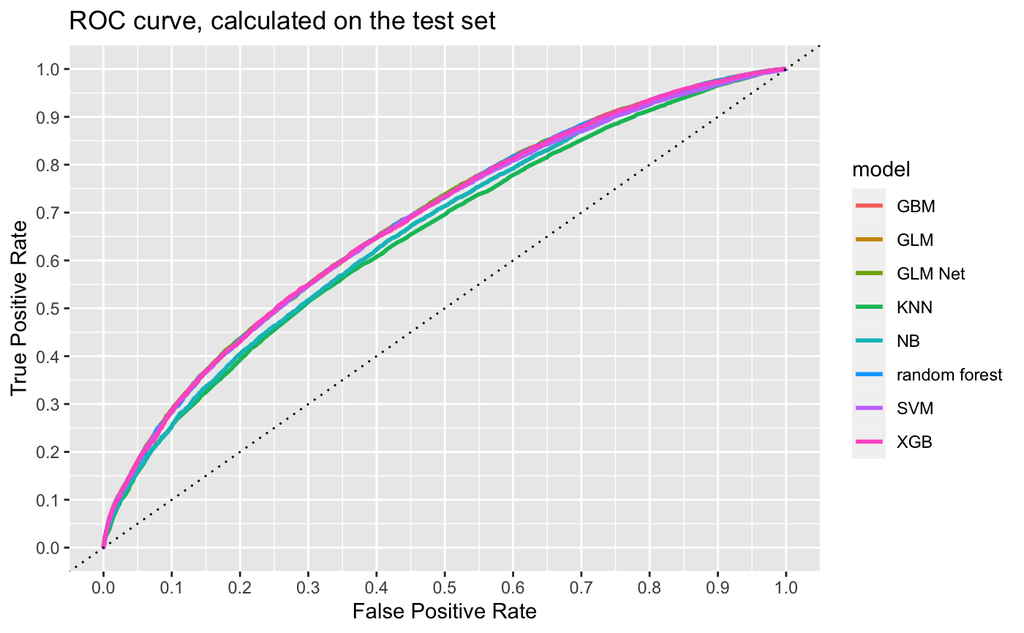

```r
roc_df_logit_rf <- imap(list("random forest" = rf_model,
                             "GLM Net" = glmnet_model,
                             "GLM" = glm_model,
                             "GBM" = gbm_model,
                             "XGB" = xgb_model,
                             "NB" = nb_model,
                             "KNN" = knn_model,
                             "SVM" = svm_model
                             ), ~ {
  model <- .x
  predicted_probabilities <- predict(model, newdata = data_holdout, type = "prob")
  rocr_prediction <- prediction(predicted_probabilities[["yes"]], data_holdout[["home_win_flag"]])

  tpr_fpr_performance <- performance(rocr_prediction, "tpr", "fpr")
  tibble(
    model = .y,
    FPR = tpr_fpr_performance@x.values[[1]],
    TPR = tpr_fpr_performance@y.values[[1]],
    cutoff = tpr_fpr_performance@alpha.values[[1]]
  )
}) %>% bind_rows()

ggplot(roc_df_logit_rf) +
  geom_line(aes(FPR, TPR, color = model), size = 1) +
  geom_abline(intercept = 0, slope = 1,  linetype = "dotted", col = "black") +
  scale_y_continuous(limits = c(0, 1), breaks = seq(0, 1, .1)) +
  scale_x_continuous(limits = c(0, 1), breaks = seq(0, 1, .1)) +
  xlab("False Positive Rate") + ylab("True Positive Rate") +
  ggtitle("ROC curve, calculated on the test set")
```

SAVE MODELS

```r
saveRDS(rf_model, paste0(output,"home_model_rf.rda"))
saveRDS(glm_model, paste0(output,"home_model_glm.rda"))
saveRDS(glmnet_model, paste0(output,"home_model_glmnet.rda"))
saveRDS(gbm_model, paste0(output,"home_model_gbm.rda"))
saveRDS(xgb_model, paste0(output,"home_model_xgb.rda"))
saveRDS(nb_model, paste0(output,"home_model_nb.rda"))
saveRDS(knn_model, paste0(output,"home_model_knn.rda"))
saveRDS(svm_model, paste0(output,"home_model_svm.rda"))
```

LOAD MODELS

```r
home_model_rf <- readRDS(paste0(output,"home_model_rf.rda"))
home_model_glm <- readRDS(paste0(output,"home_model_glm.rda"))
home_model_gbm <- readRDS(paste0(output,"home_model_gbm.rda"))
home_model_xgb <- readRDS(paste0(output,"home_model_xgb.rda"))
home_model_nb <- readRDS(paste0(output,"home_model_nb.rda"))
home_model_knn <- readRDS(paste0(output,"home_model_knn.rda"))
home_model_svm <- readRDS(paste0(output,"home_model_svm.rda"))
```

TRY LOADED MODEL

```r
# AUC on holdout set
predicted_proba_holdout <- predict(home_model_rf,
                         newdata = data_holdout,
                         type = "prob")[["yes"]]


prediction_holdout_proba <- prediction(predicted_proba_holdout, data_holdout$home_win_flag)
auc_holdout_proba <- performance(prediction_holdout_proba, measure = "auc")@y.values[[1]]
message(paste0("AUC on holdout set for RF: ", round(auc_holdout_proba, digits = 4)))
```

[output not shown]

CALIBRATION TEST

```r
# calibration plot: how well do estimated vs actual event probabilities relate to each other?
# -------------------------------------------------
actual_vs_predicted_rf1 <- data.frame(
  actual = ifelse(data_holdout[["home_win_flag"]] == "yes", 1, 0),
  predicted = predicted_rf1_holdout
)
```

```
Error in data.frame(actual = ifelse(data_holdout[["home_win_flag"]] ==  :
  object 'predicted_rf1_holdout' not found
```